# Test a Perceptual Phenomenon

### Analyzing the Stroop Effect

In this report we'll analyze a dataset contains results from a number of participants in a Stroop Task.

In a Stroop task, participants are presented with a list of words, with each word displayed in a color of ink. The participant’s task is to say out loud the color of the ink in which the word is printed. The task has two conditions: a congruent words condition, and an incongruent words condition. In the congruent words condition, the words being displayed are color words whose names match the colors in which they are printed: for example RED, BLUE. In the incongruent words condition, the words displayed are color words whose names do not match the colors in which they are printed: for example PURPLE, ORANGE. In each case, we measure the time it takes to name the ink colors in equally-sized lists. Each participant will go through and record a time from each condition.

Each row of the dataset contains the performance for one participant, with the first number their results on the congruent task and the second number their performance on the incongruent task.

**(1) variables**

```python
import pandas as pd
data = pd.read_csv('stroopdata.csv')
data.head()
```

|  | Congruent | Incongruent |
| --- | --- | --- |
| 0 | 12.079 | 19.278 |
| 1 | 16.791 | 18.741 |
| 2 | 9.564 | 21.214 |
| 3 | 8.630 | 15.687 |
| 4 | 14.669 | 22.803 |

Independent Variable: The condition the words shown(congruent with the ink colors or incongruent with the ink colors)  
Dependent Variable: The time taken by the participant to correctly read the word.

**(2) Hypotheses**

**Null hypotheses($H_0$):** The average response time for each participant in congruent and incongruent tasks is the same.  
**Alternative hypothesee($H_1$):**There is a differnce in the average response time if a participant reads a word under congrunet or incongruent condition.

$$H_0:\mu_{C}-\mu_{I}=0$$ $$H_1:\mu_{C}-\mu_{I} != 0$$

$\mu_{C}$ stands for our population average response time under congruent condition, and $\mu_{I}$ stands for our population average response time under incongruent condtion.

We're going to do a **paired t_test**. In order for the paired sample t-test results to be trusted, the following **assumptions** need to be met:

- The dependent variable should be continuous. As we know congruent and incongruent are the average respond time by participants, and time is a continuouse value.
- The dependant variable should be approximately normally distributed. We'll check the distribution in section (3).
- The dependent variable should not contain any outliers. We'll check the outliers in section (3).

**(3) Descriptive Statistics**

```python
data['Congruent'].mean() , data['Incongruent'].mean()
```

```
(14.051124999999999, 22.015916666666666)
```

the average response time by participants is 14 seconds in congruent way and 22 seconds in incongruent.

```python
data.describe()
```

|  | Congruent | Incongruent |
| --- | --- | --- |
| count | 24.000000 | 24.000000 |
| mean | 14.051125 | 22.015917 |
| std | 3.559358 | 4.797057 |
| min | 8.630000 | 15.687000 |
| 25% | 11.895250 | 18.716750 |
| 50% | 14.356500 | 21.017500 |
| 75% | 16.200750 | 24.051500 |
| max | 22.328000 | 35.255000 |

For 24 records we have collected, response time ranges between 8.63 to 22.33 seconds under congruent condition, and between 15.69 to 35.26 seconds under incongruent condition.

**(4) Visualizations**

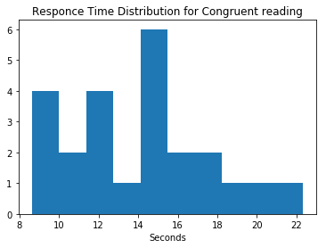

```python
import matplotlib.pyplot as plt
%matplotlib inline
plt.hist(data['Congruent'])
plt.xlabel('Seconds')
plt.title('Responce Time Distribution for Congruent reading');
```

The response time in congruent reading is almost normally distributed.

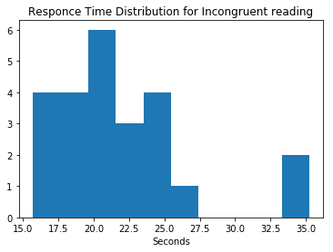

```python
plt.hist(data['Incongruent'])
plt.xlabel('Seconds')
plt.title('Responce Time Distribution for Incongruent reading');
```

The response time for incongruent reading is almost normally distribeted. there are outliers in our data, but they are minor.

We could see our dependant variable are almost normally distributed and there aren't major outliers in our data, so our assumptions for t-test are met.

**(5) statistical test**

```python
import scipy.stats as stats
stats.ttest_rel(data['Congruent'], data['Incongruent'])
```

```
Ttest_relResult(statistic=-8.020706944109957, pvalue=4.1030005857111781e-08)
```